# Human Activity Recognition (HAR)

Johannes Marais

21 November 2015

## Introduction

The [dataset](http://groupware.les.inf.puc-rio.br/static/WLE/WearableComputing_weight_lifting_exercises_biceps_curl_variations.csv) is of six people who were asked to perform one set of 10 repetitions of the Unilateral Dumbbell Biceps Curl. It was done in five different fashions and is stored in the ‘classe’ variable in the dataset:

- A: Exactly according to the specification
- B: Throwing the elbows to the front
- C: Lifting the dumbbell only halfway
- D: Lowering the dumbbell only halfway
- E: Throwing the hips to the front

The aim of this project is to create a model that given some variables, will be able to predict in which fashion an exercise was done.

## Data processing

In this section, the data will be downloaded, opened and formatted ready to set up the model.

### Setting up the environment and loading the required libraries

```r
library(caret)
setwd("~/Documents/Coursera/Specialization/08 Practical machine learning/Project") #Change as required
set.seed(1) #Set the seed of the predictions to make the results reproducible
```

### Downloading the data

```r
setwd("~/Documents/Coursera/Specialization/08 Practical machine learning/Project/Project")
trainingDataUrl<-"https://d396qusza40orc.cloudfront.net/predmachlearn/pml-training.csv"
testingDataUrl<-"https://d396qusza40orc.cloudfront.net/predmachlearn/pml-testing.csv"
download.file(trainingDataUrl, "pml-training.csv", method="curl")
download.file(testingDataUrl, "pml-testing.csv", method="curl")
```

### Loading the data

```r
activity_Data<-read.csv("pml-training.csv",na.strings = c("NA"," ",""))
activity_Data_test<-read.csv("pml-testing.csv",na.strings = c("NA"," ",""))
dim(activity_Data)
```

```
## [1] 19622   160
```

```r
dim(activity_Data_test)
```

```
## [1]  20 160
```

### Preprocessing the data

```r
trainingSetNAMap<-colSums(!is.na(activity_Data)) #Check how many values of NA are in the dataset per column
table(trainingSetNAMap)
```

```
## trainingSetNAMap
##   406 19622
##   100    60
```

From this table it can be seen that there are 60 columns from the 160 has 19622 non NA values. The remaining 100 columns have 406 non NA values and these columns will be removed from the dataset that will be analysed.

```r
columnsToRemove<- trainingSetNAMap==406 #Check where the rows are with the 406 non NA values for removal
activity_Data_Subset<- activity_Data[!columnsToRemove]
dim(activity_Data_Subset)
```

```
## [1] 19622    60
```

There are now only 60 variables in the dataset. Let us take a look at the dataset:

```r
names(activity_Data_Subset)
```

```
##  [1] "X"                    "user_name"            "raw_timestamp_part_1"
##  [4] "raw_timestamp_part_2" "cvtd_timestamp"       "new_window"
##  [7] "num_window"           "roll_belt"            "pitch_belt"
## [10] "yaw_belt"             "total_accel_belt"     "gyros_belt_x"
## [13] "gyros_belt_y"         "gyros_belt_z"         "accel_belt_x"
## [16] "accel_belt_y"         "accel_belt_z"         "magnet_belt_x"
## [19] "magnet_belt_y"        "magnet_belt_z"        "roll_arm"
## [22] "pitch_arm"            "yaw_arm"              "total_accel_arm"
## [25] "gyros_arm_x"          "gyros_arm_y"          "gyros_arm_z"
## [28] "accel_arm_x"          "accel_arm_y"          "accel_arm_z"
## [31] "magnet_arm_x"         "magnet_arm_y"         "magnet_arm_z"
## [34] "roll_dumbbell"        "pitch_dumbbell"       "yaw_dumbbell"
## [37] "total_accel_dumbbell" "gyros_dumbbell_x"     "gyros_dumbbell_y"
## [40] "gyros_dumbbell_z"     "accel_dumbbell_x"     "accel_dumbbell_y"
## [43] "accel_dumbbell_z"     "magnet_dumbbell_x"    "magnet_dumbbell_y"
## [46] "magnet_dumbbell_z"    "roll_forearm"         "pitch_forearm"
## [49] "yaw_forearm"          "total_accel_forearm"  "gyros_forearm_x"
## [52] "gyros_forearm_y"      "gyros_forearm_z"      "accel_forearm_x"
## [55] "accel_forearm_y"      "accel_forearm_z"      "magnet_forearm_x"
## [58] "magnet_forearm_y"     "magnet_forearm_z"     "classe"
```

As can be seen some ‘administrative’ variables are still in the datasets. These are username, row number, times stamp and the measuring windows. These will be removed next:

```r
activity_Data_Subset<- activity_Data_Subset[-(1:7)]
dim(activity_Data_Subset)
```

```
## [1] 19622    53
```

## Building the model

The data will be split into a training and a test set to verify the accuracy of this model. The training set will be 70% and the test set 30% of the full data set.

```r
inTrain<- createDataPartition(activity_Data_Subset$classe,p=0.7,list = FALSE)
training<- activity_Data_Subset[inTrain,]
testing<- activity_Data_Subset[-inTrain,]
dim(training)
```

```
## [1] 13737    53
```

```r
dim(testing)
```

```
## [1] 5885   53
```

### Training the model

The Random Forest training model will be used. A low k cross validation was used for this model to save processing time. With k=3, this model takes almost 23 minutes to compute on an older single core pc.

```r
timeNow<- Sys.time()
modfit<- train(classe ~ ., data = training, method = "rf", prox = TRUE,
      trControl = trainControl(method = "cv", number = 3, allowParallel = TRUE))
Sys.time()-timeNow
```

```
## Time difference of 22.539 mins
```

```r
modfit$finalModel
```

```
##
## Call:
##  randomForest(x = x, y = y, mtry = param$mtry, proximity = TRUE)
##                Type of random forest: classification
##                      Number of trees: 500
## No. of variables tried at each split: 27
##
##         OOB estimate of  error rate: 0.71%
## Confusion matrix:
##      A    B    C    D    E class.error
## A 3901    2    1    1    1 0.001280082
## B   23 2629    5    1    0 0.010910459
## C    0   12 2370   14    0 0.010851419
## D    0    2   20 2228    2 0.010657194
## E    0    3    4    6 2512 0.005148515
```

With k=4, the computation takes 34 minutes.

```r
timeNow<- Sys.time()
modfit4<- train(classe ~ ., data = training, method = "rf", prox = TRUE,
      trControl = trainControl(method = "cv", number = 4, allowParallel = TRUE))
Sys.time()-timeNow
```

```
## Time difference of 34.04884 mins
```

```r
modfit4$finalModel
```

```
##
## Call:
##  randomForest(x = x, y = y, mtry = param$mtry, proximity = TRUE)
##                Type of random forest: classification
##                      Number of trees: 500
## No. of variables tried at each split: 2
##
##         OOB estimate of  error rate: 0.6%
## Confusion matrix:
##      A    B    C    D    E class.error
## A 3906    0    0    0    0 0.000000000
## B   14 2640    4    0    0 0.006772009
## C    0   20 2374    2    0 0.009181970
## D    0    0   37 2213    2 0.017317940
## E    0    0    1    3 2521 0.001584158
```

With k=5, the computation takes 48 minutes.

```r
timeNow<- Sys.time()
modfit5<- train(classe ~ ., data = training, method = "rf", prox = TRUE,
      trControl = trainControl(method = "cv", number = 5, allowParallel = TRUE))
Sys.time()-timeNow
```

```
## Time difference of 47.86678 mins
```

```r
modfit5$finalModel
```

```
##
## Call:
##  randomForest(x = x, y = y, mtry = param$mtry, proximity = TRUE)
##                Type of random forest: classification
##                      Number of trees: 500
## No. of variables tried at each split: 2
##
##         OOB estimate of  error rate: 0.63%
## Confusion matrix:
##      A    B    C    D    E class.error
## A 3906    0    0    0    0 0.000000000
## B   13 2640    5    0    0 0.006772009
## C    0   21 2374    1    0 0.009181970
## D    0    0   41 2210    1 0.018650089
## E    0    0    1    3 2521 0.001584158
```

The in sample accuracy between the models are shown below:

```r
modfit
```

```
## Random Forest
##
## 13737 samples
##    52 predictor
##     5 classes: 'A', 'B', 'C', 'D', 'E'
##
## No pre-processing
## Resampling: Cross-Validated (3 fold)
## Summary of sample sizes: 9157, 9158, 9159
## Resampling results across tuning parameters:
##
##   mtry  Accuracy   Kappa      Accuracy SD  Kappa SD
##    2    0.9862419  0.9825931  0.002644927  0.003344829
##   27    0.9879159  0.9847126  0.002272558  0.002873772
##   52    0.9786710  0.9730135  0.001691931  0.002137683
##
## Accuracy was used to select the optimal model using  the largest value.
## The final value used for the model was mtry = 27.
```

```r
modfit4
```

```
## Random Forest
##
## 13737 samples
##    52 predictor
##     5 classes: 'A', 'B', 'C', 'D', 'E'
##
## No pre-processing
## Resampling: Cross-Validated (4 fold)
## Summary of sample sizes: 10304, 10303, 10303, 10301
## Resampling results across tuning parameters:
##
##   mtry  Accuracy   Kappa      Accuracy SD  Kappa SD
##    2    0.9906821  0.9882124  0.001594815  0.002017017
##   27    0.9903913  0.9878449  0.001320470  0.001669974
##   52    0.9812183  0.9762361  0.001694703  0.002146789
##
## Accuracy was used to select the optimal model using  the largest value.
## The final value used for the model was mtry = 2.
```

```r
modfit5
```

```
## Random Forest
##
## 13737 samples
##    52 predictor
##     5 classes: 'A', 'B', 'C', 'D', 'E'
##
## No pre-processing
## Resampling: Cross-Validated (5 fold)
## Summary of sample sizes: 10989, 10989, 10990, 10990, 10990
## Resampling results across tuning parameters:
##
##   mtry  Accuracy   Kappa      Accuracy SD  Kappa SD
##    2    0.9919196  0.9897790  0.001553272  0.001965026
##   27    0.9911917  0.9888580  0.001465023  0.001853194
##   52    0.9837665  0.9794626  0.003645450  0.004613678
##
## Accuracy was used to select the optimal model using  the largest value.
## The final value used for the model was mtry = 2.
```

### Importance of the different variables

The importance for the model of k=5 is shown below:

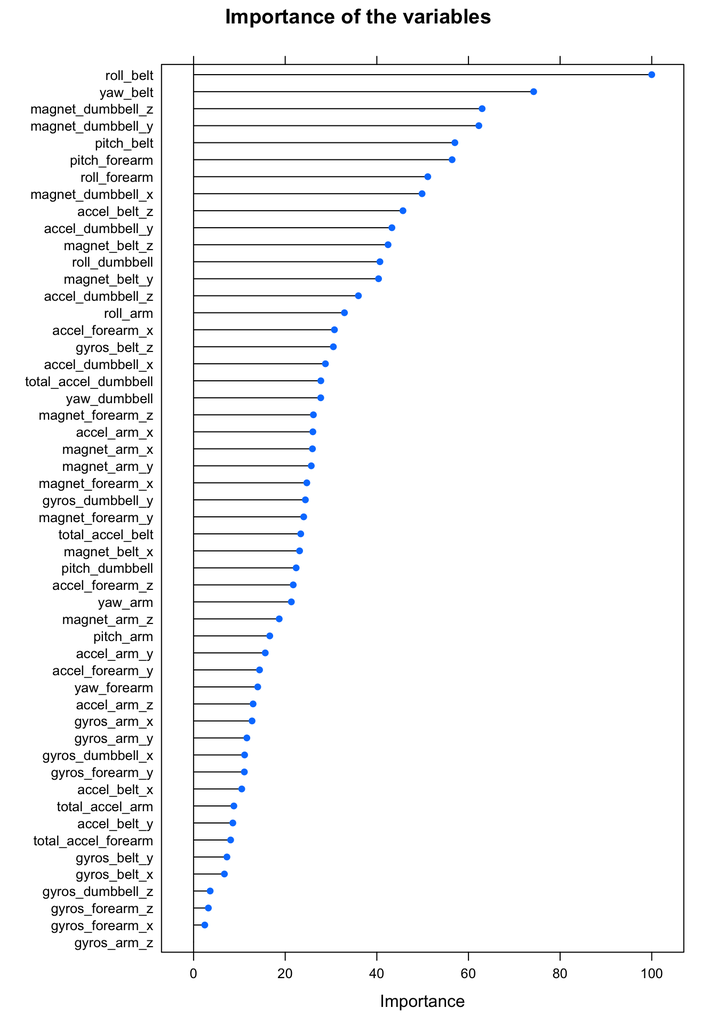

```r
plot(varImp(modfit5),main="Importance of the variables")
```

### Testing the models on the test data set.

The models for k=3,4 and 5 are tested on the test data set which was created in the Data PRocessing section above.

#### k=3

```r
pred3<-predict(modfit,testing) #Prediction when k=3 on the test set
confusionMatrix(pred3,testing$classe)
```

```
## Confusion Matrix and Statistics
##
##           Reference
## Prediction    A    B    C    D    E
##          A 1673    2    0    0    0
##          B    1 1133    6    0    0
##          C    0    4 1013   18    2
##          D    0    0    7  945    3
##          E    0    0    0    1 1077
##
## Overall Statistics
##
##                Accuracy : 0.9925
##                  95% CI : (0.99, 0.9946)
##     No Information Rate : 0.2845
##     P-Value [Acc > NIR] : < 2.2e-16
##
##                   Kappa : 0.9905
##  Mcnemar's Test P-Value : NA
##
## Statistics by Class:
##
##                      Class: A Class: B Class: C Class: D Class: E
## Sensitivity            0.9994   0.9947   0.9873   0.9803   0.9954
## Specificity            0.9995   0.9985   0.9951   0.9980   0.9998
## Pos Pred Value         0.9988   0.9939   0.9769   0.9895   0.9991
## Neg Pred Value         0.9998   0.9987   0.9973   0.9961   0.9990
## Prevalence             0.2845   0.1935   0.1743   0.1638   0.1839
## Detection Rate         0.2843   0.1925   0.1721   0.1606   0.1830
## Detection Prevalence   0.2846   0.1937   0.1762   0.1623   0.1832
## Balanced Accuracy      0.9995   0.9966   0.9912   0.9891   0.9976
```

#### k=4

```r
pred4<-predict(modfit4,testing) #Prediction when k=4 on the test set
confusionMatrix(pred4,testing$classe)
```

```
## Confusion Matrix and Statistics
##
##           Reference
## Prediction    A    B    C    D    E
##          A 1673    7    0    0    0
##          B    1 1131   10    0    0
##          C    0    1 1015   19    0
##          D    0    0    1  945    2
##          E    0    0    0    0 1080
##
## Overall Statistics
##
##                Accuracy : 0.993
##                  95% CI : (0.9906, 0.995)
##     No Information Rate : 0.2845
##     P-Value [Acc > NIR] : < 2.2e-16
##
##                   Kappa : 0.9912
##  Mcnemar's Test P-Value : NA
##
## Statistics by Class:
##
##                      Class: A Class: B Class: C Class: D Class: E
## Sensitivity            0.9994   0.9930   0.9893   0.9803   0.9982
## Specificity            0.9983   0.9977   0.9959   0.9994   1.0000
## Pos Pred Value         0.9958   0.9904   0.9807   0.9968   1.0000
## Neg Pred Value         0.9998   0.9983   0.9977   0.9962   0.9996
## Prevalence             0.2845   0.1935   0.1743   0.1638   0.1839
## Detection Rate         0.2843   0.1922   0.1725   0.1606   0.1835
## Detection Prevalence   0.2855   0.1941   0.1759   0.1611   0.1835
## Balanced Accuracy      0.9989   0.9953   0.9926   0.9898   0.9991
```

#### k=5

```r
pred5<-predict(modfit5,testing) #Prediction when k=5 on the test set
confusionMatrix(pred5,testing$classe)
```

```
## Confusion Matrix and Statistics
##
##           Reference
## Prediction    A    B    C    D    E
##          A 1673    5    0    0    0
##          B    1 1133    8    0    0
##          C    0    1 1018   17    0
##          D    0    0    0  947    2
##          E    0    0    0    0 1080
##
## Overall Statistics
##
##                Accuracy : 0.9942
##                  95% CI : (0.9919, 0.996)
##     No Information Rate : 0.2845
##     P-Value [Acc > NIR] : < 2.2e-16
##
##                   Kappa : 0.9927
##  Mcnemar's Test P-Value : NA
##
## Statistics by Class:
##
##                      Class: A Class: B Class: C Class: D Class: E
## Sensitivity            0.9994   0.9947   0.9922   0.9824   0.9982
## Specificity            0.9988   0.9981   0.9963   0.9996   1.0000
## Pos Pred Value         0.9970   0.9921   0.9826   0.9979   1.0000
## Neg Pred Value         0.9998   0.9987   0.9984   0.9966   0.9996
## Prevalence             0.2845   0.1935   0.1743   0.1638   0.1839
## Detection Rate         0.2843   0.1925   0.1730   0.1609   0.1835
## Detection Prevalence   0.2851   0.1941   0.1760   0.1613   0.1835
## Balanced Accuracy      0.9991   0.9964   0.9942   0.9910   0.9991
```

As can be seen, all three these models fare well when predicting the test data and comparing them with the actual data. The accuracy improves as the k-folds increases but at a cost of computing time. All three these models have an accuracy better than 99.2% when tested on the test set.

## References

- [Data source](http://groupware.les.inf.puc-rio.br/static/WLE/WearableComputing_weight_lifting_exercises_biceps_curl_variations.csv)
- http://groupware.les.inf.puc-rio.br/har